# Part II - Relationship between trip duration and member age

## by Inioluwa Mofiyinfoluwa Olaniran

## Investigation Overview

> In this investigation/presentation, we are going to look at how the trip duration and member age relate and affect each other.

## Dataset Overview

> This data set includes information about individual rides made in a bike-sharing system covering the greater San Francisco Bay area. It has 183412 observations (rows) with 16 features (columns). The dataset has datatypes int64(2), float64(7) and object (7). After cleaning techniques were carried on the dataset, there were 173768 observations (rows) and 13 features (columns) with datatypes category(3), datetime64(2), int64(3) and object(5).

## (Visualization 1)

> Trip Duration Distribution Plot. A regular histogram was plotted but a long tail was shown in the results so the plot was transfered to a log scale type of plot to understand the data better.

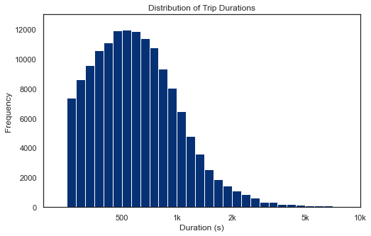

## (Visualization 2)

> Member_age Distribution Plot. Users from an age between ages 30-35 bike the most as they have a higher frequency on the distribution plot.

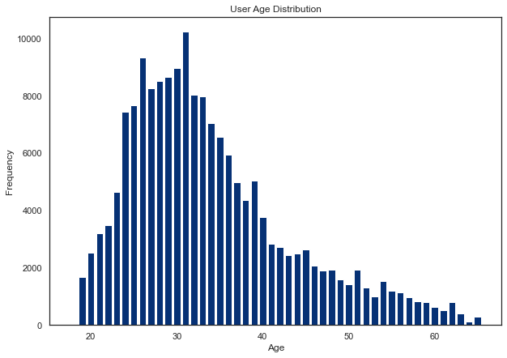

## (Visualization 3)

> The plot shows that the duration is more concentrated from age 20 to 50. Also, as the age increases, the trip duration decreases.

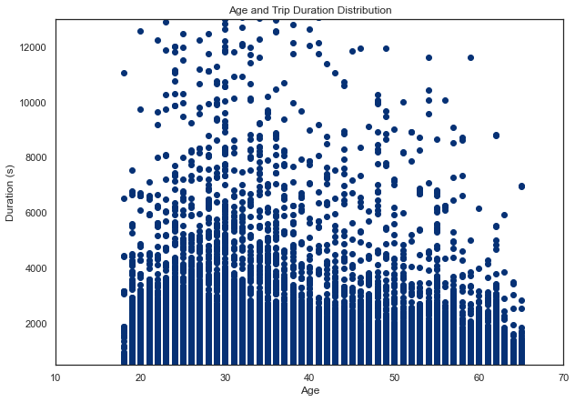

## (Visualization 4)

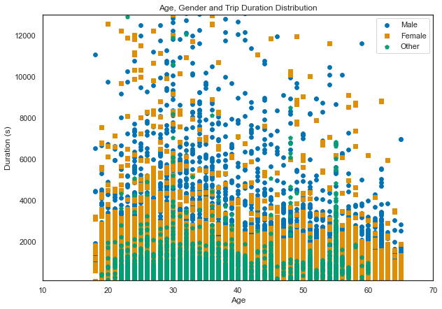

## (Visualization 5)

> The three plots shows that males are more active as their plot is more concentrated than the other two meaning males have more trip durations than the other genders and the duration decreases as they get older.

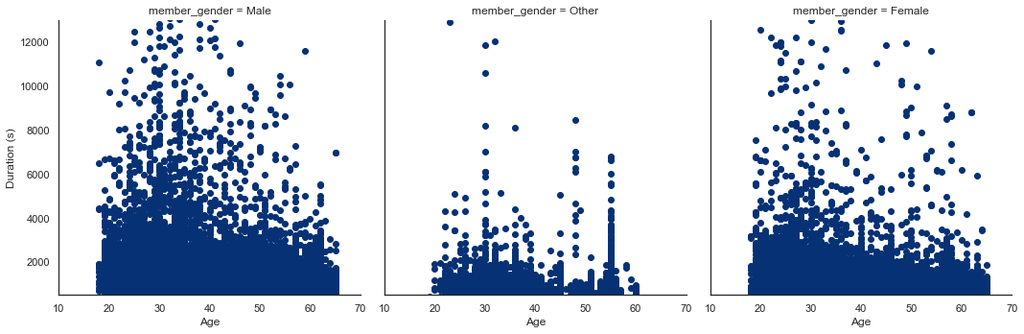

## Summary of Findings

> All the plots helped to find that as a user ages (no matter type or gender), the trip duration reduces significantly. The ages where the trip duration is the strongest is between ages twenty (20) to fifty (50).